# Vigilância de mortalidade no Alto Tâmega e Barroso

### Outras partes e partes não especificadas do útero

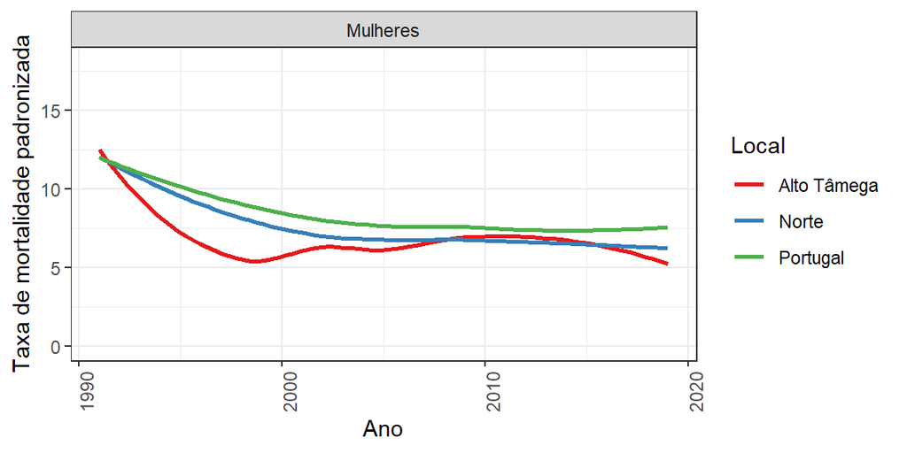

### Ovário

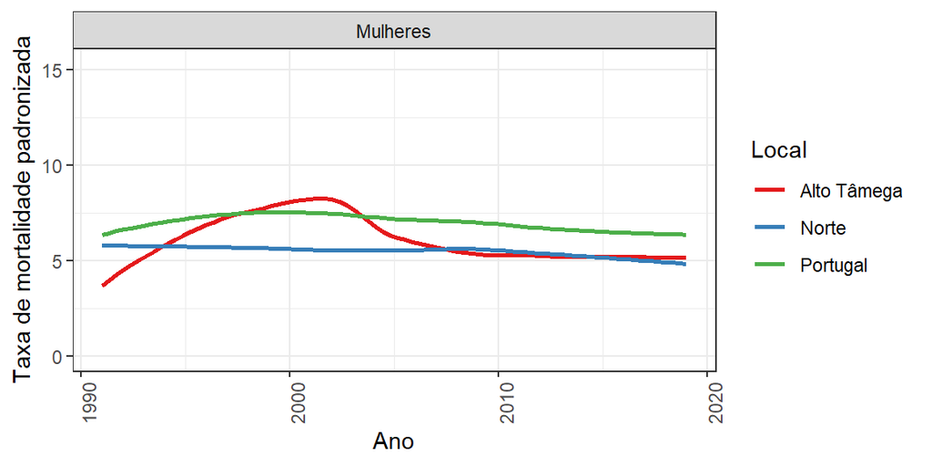

### Próstata

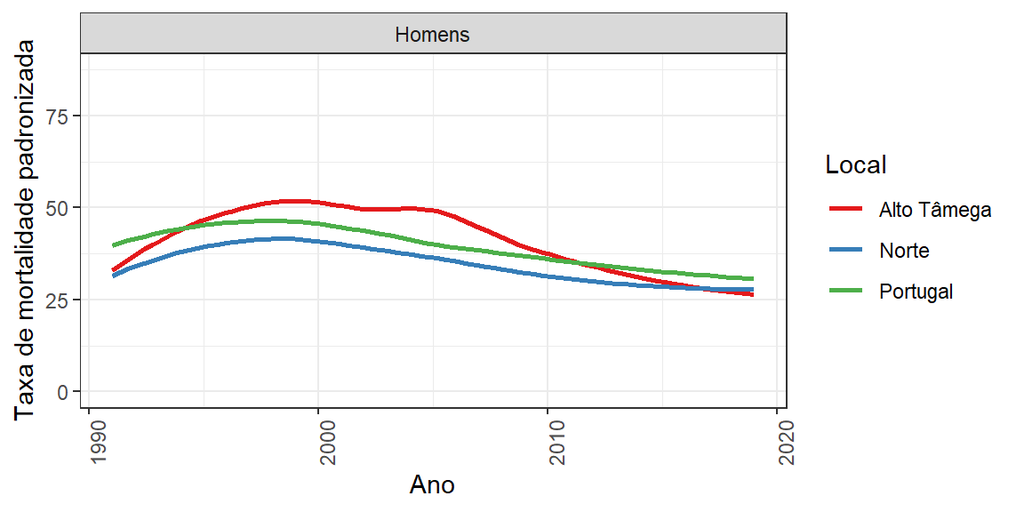

### Rim, excepto pelve renal

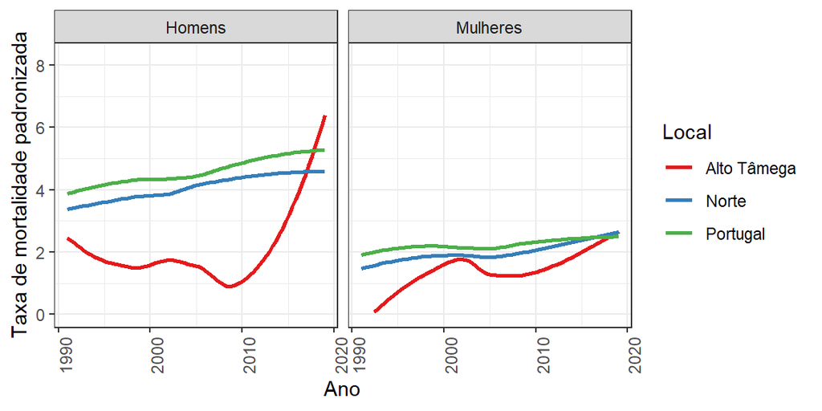

### Bexiga

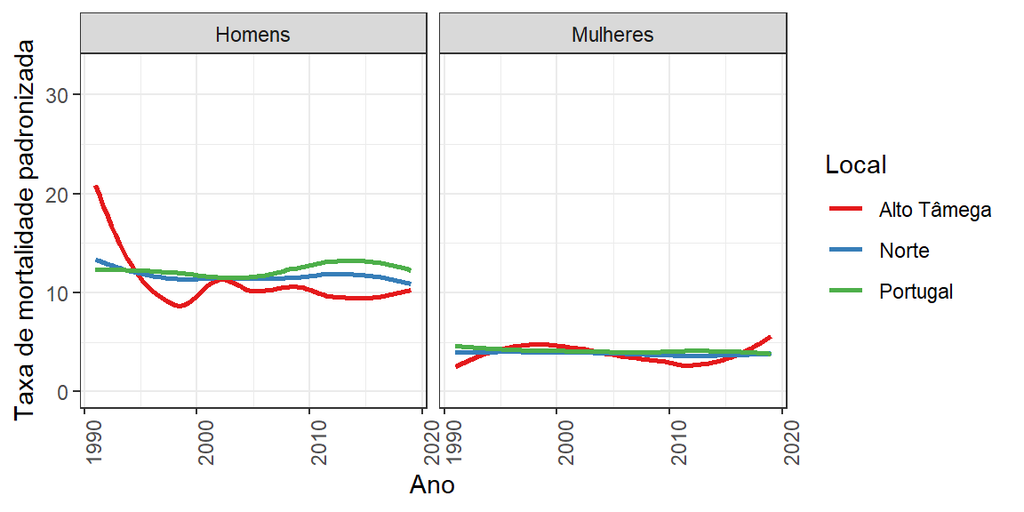

### Tecido linfático e hematopoético e tecidos relacionados

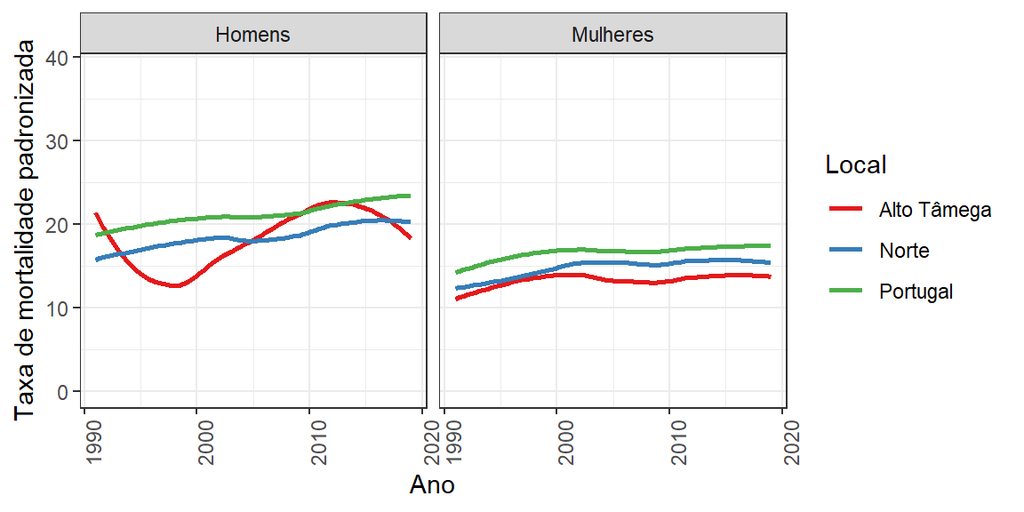

# Doenças hematológicas e imunitárias

## Coluna 1

### Doenças do sangue e dos órgãos hematopoéticos e alguns transtornos imunitários

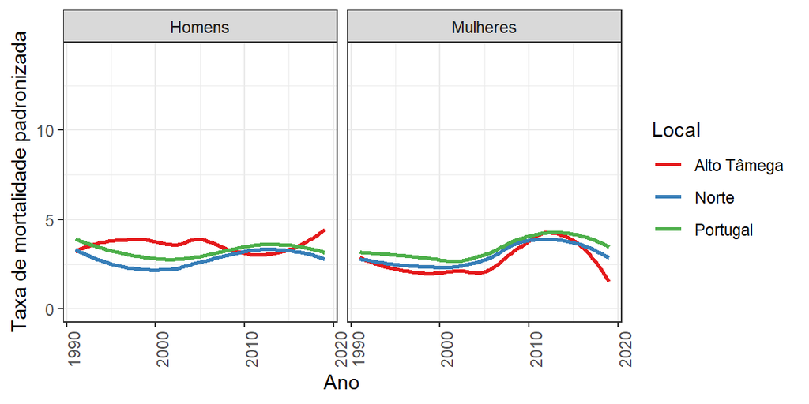

# Doenças endócrinas

## Coluna 1

### Doenças endócrinas, nutricionais e metabólicas

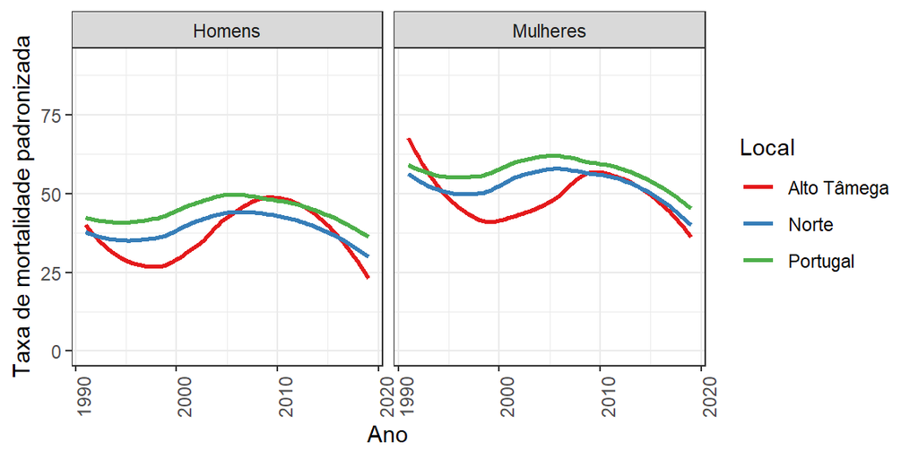

## Coluna 2

### Diabetes mellitus

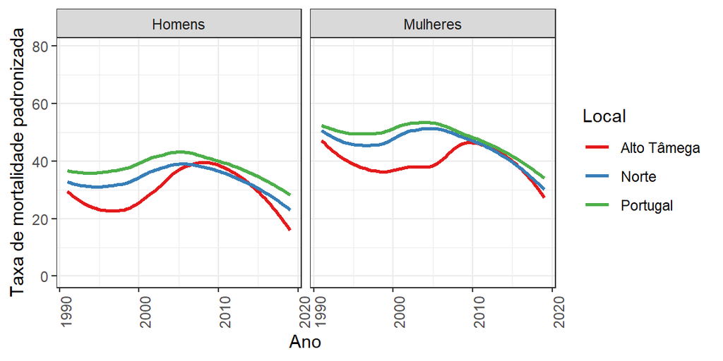

# Doenças mentais

## Coluna 1

### Transtornos mentais e comportamentais

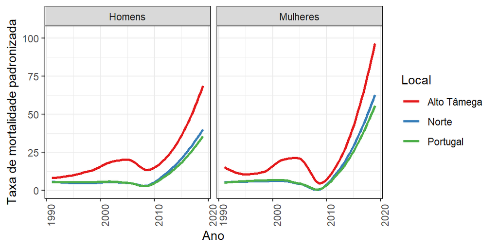

## Coluna 2

### Transtornos mentais e comportamentais devidos ao uso de álcool

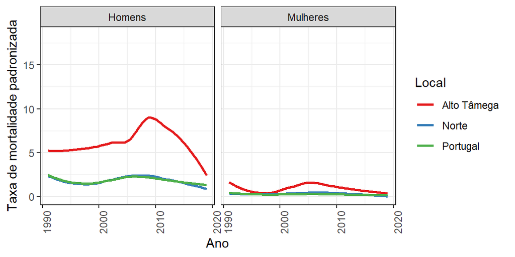

### Dependência de drogas (toxicomania)

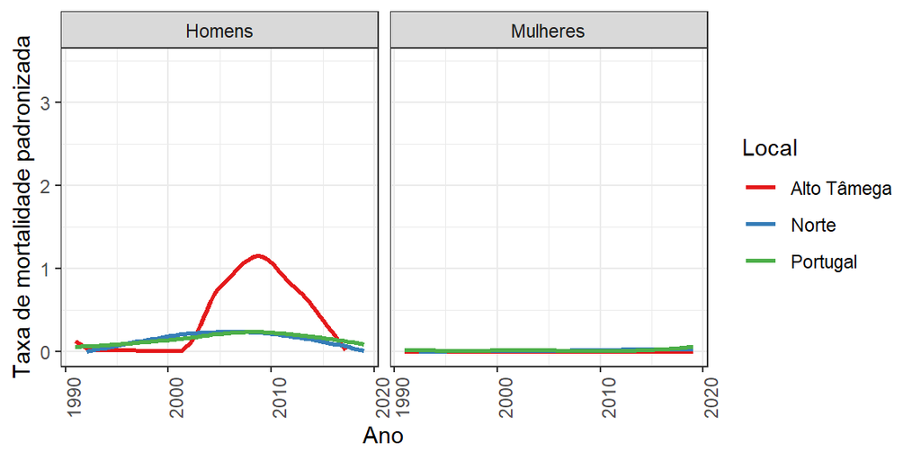

# Doenças do sistema nervoso

## Coluna 1

### Doenças do sistema nervoso e dos órgãos dos sentidos

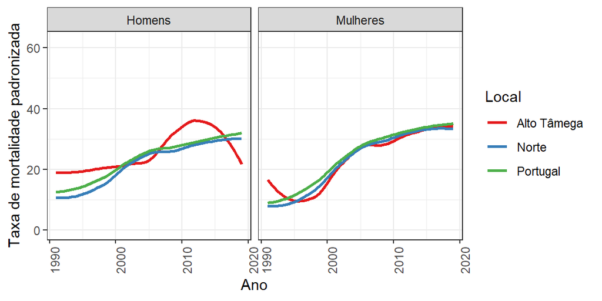

## Coluna 2

### Meningites (excepto infecção meningocócica)

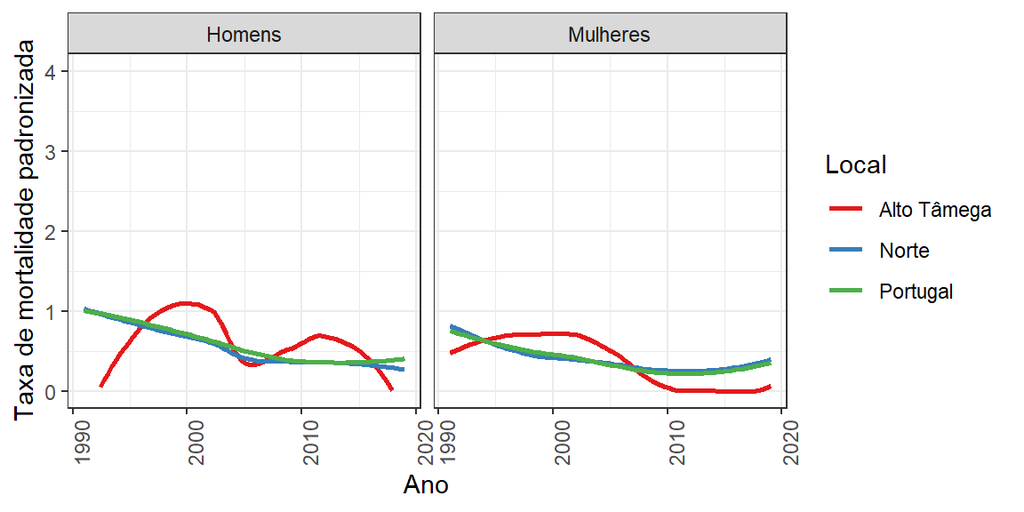

# Doenças do aparelho circulatório

## Coluna 1

### Doenças do aparelho circulatório

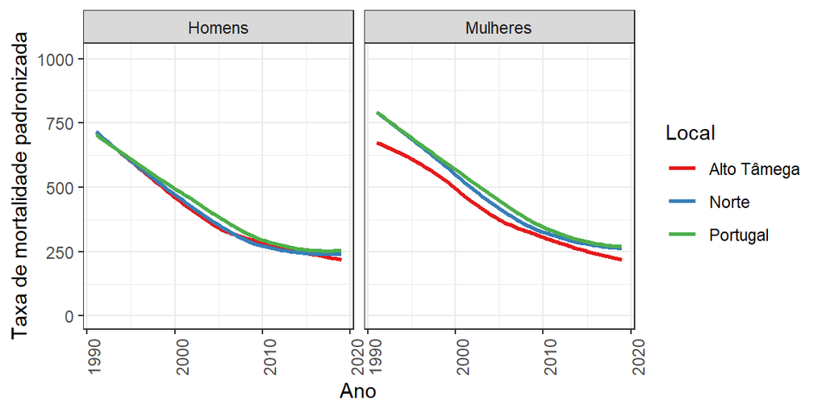

## Coluna 2

### Doenças isquémicas do coração

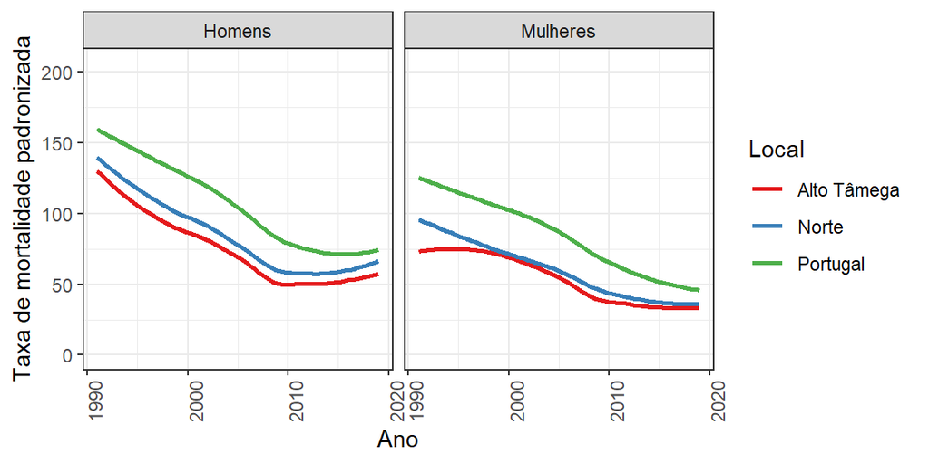

### Outras doenças cardíacas (excepto transtornos valvulares não-reumáticos e doenças valvulares)

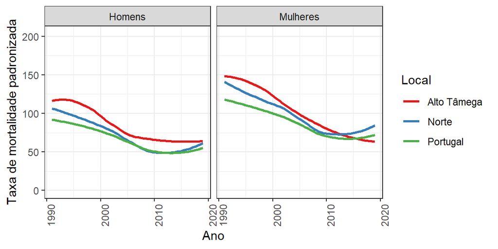

### Doenças cérebro-vasculares

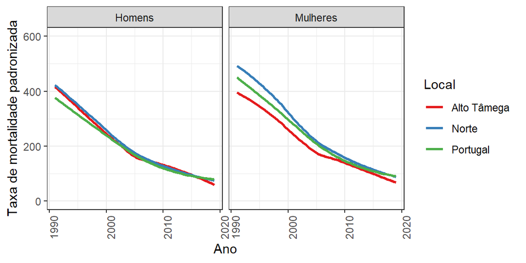

# Doenças do aparelho respiratório

## Coluna 1

### Doenças do aparelho respiratório

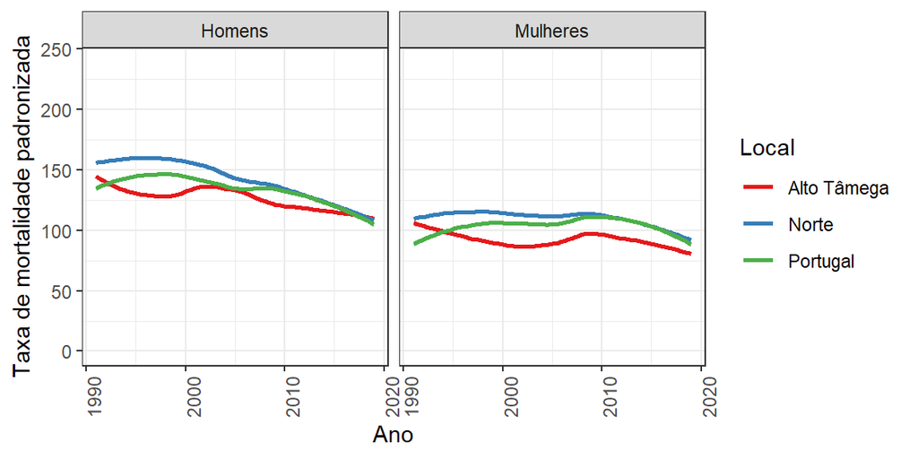

## Coluna 2

### Gripe (Influenza)

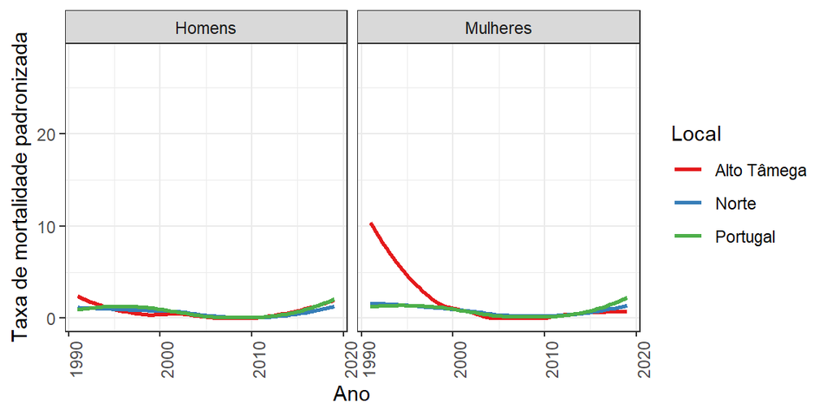

### Pneumonia

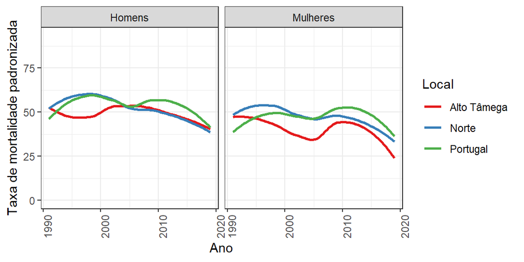

### Doenças crónicas das vias aéreas inferiores

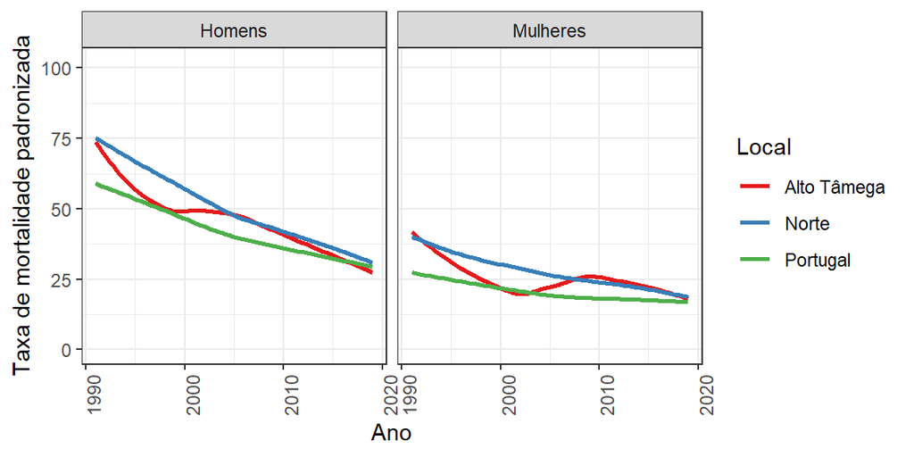

### Asma e estado de mal asmático

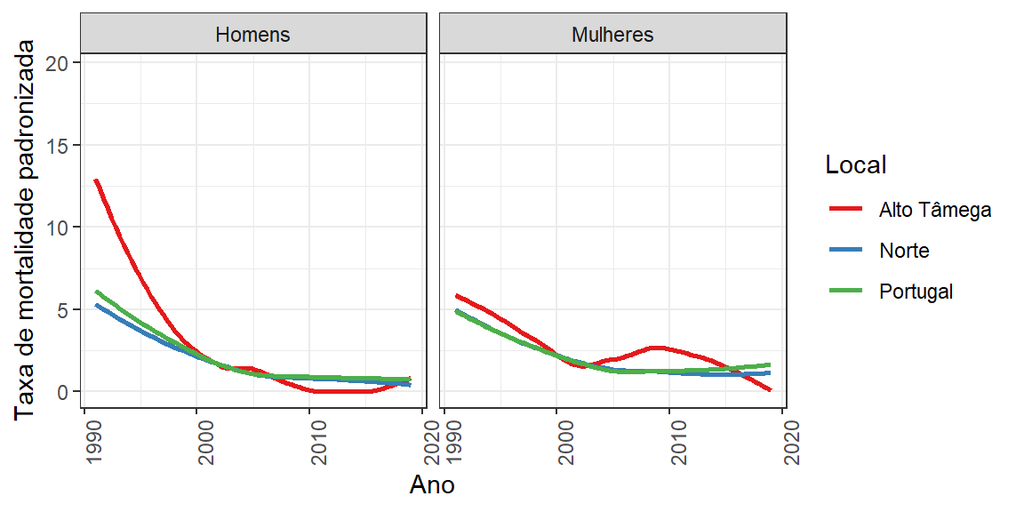

# Doenças do aparelho digestivo

## Coluna 1

### Doenças do aparelho digestivo

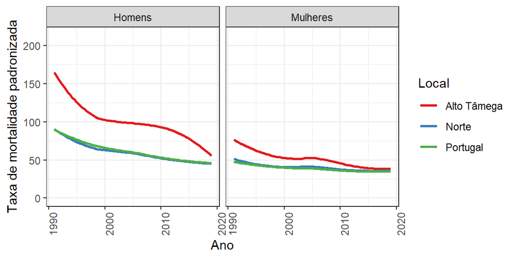

## Coluna 2

### Úlcera gástrica, duodenal, péptica de localização não especificada e gastrojejunal

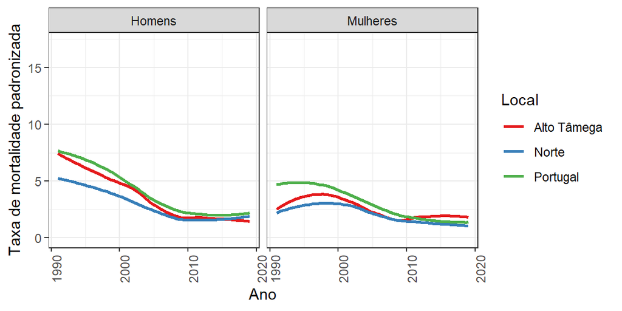

### Doenças crónicas do fígado

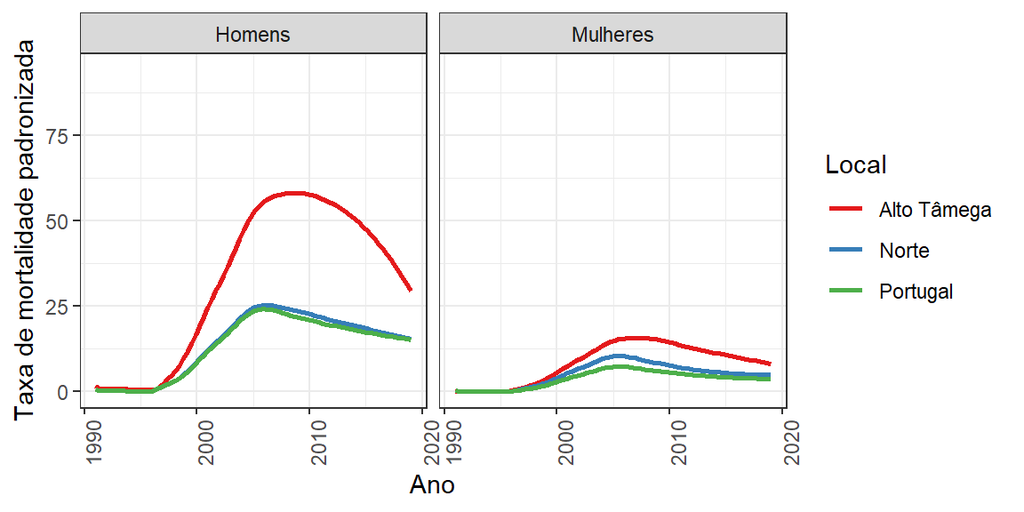

# Doenças da pele

## Coluna 1

### Doenças da pele e do tecido celular subcutâneo

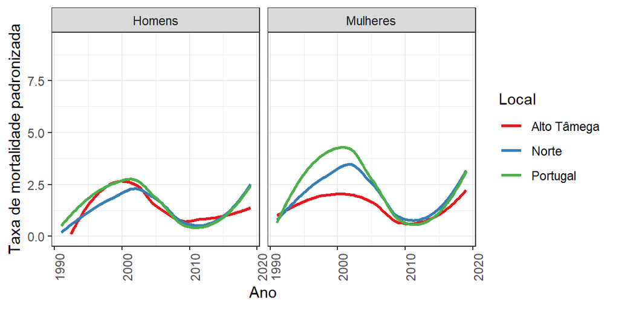

# Doenças osteomusculares

## Coluna 1

### Doenças do sistema osteomuscular e tecido conjuntivo

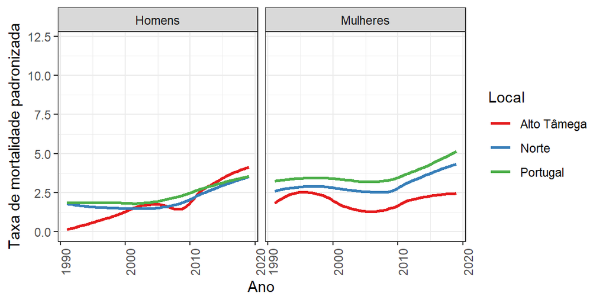

## Coluna 2

### Artrites reumatóides e artroses

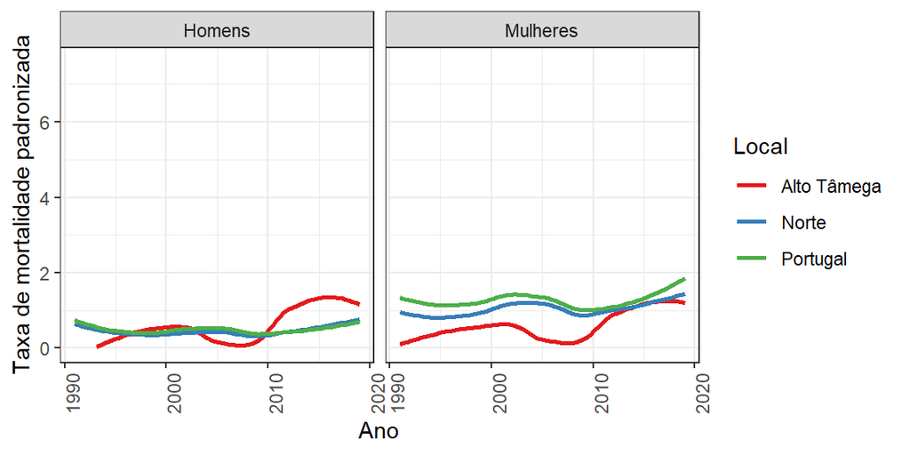

# Doenças do aparelho geniturinário

## Coluna 1

### Doenças do aparelho geniturinário

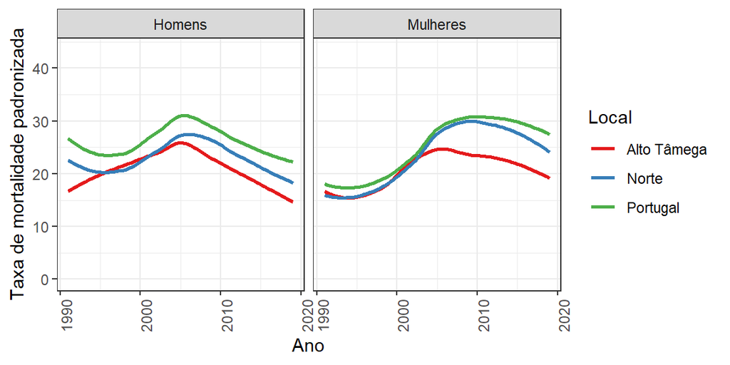

## Coluna 2

### Doenças do rim e ureter

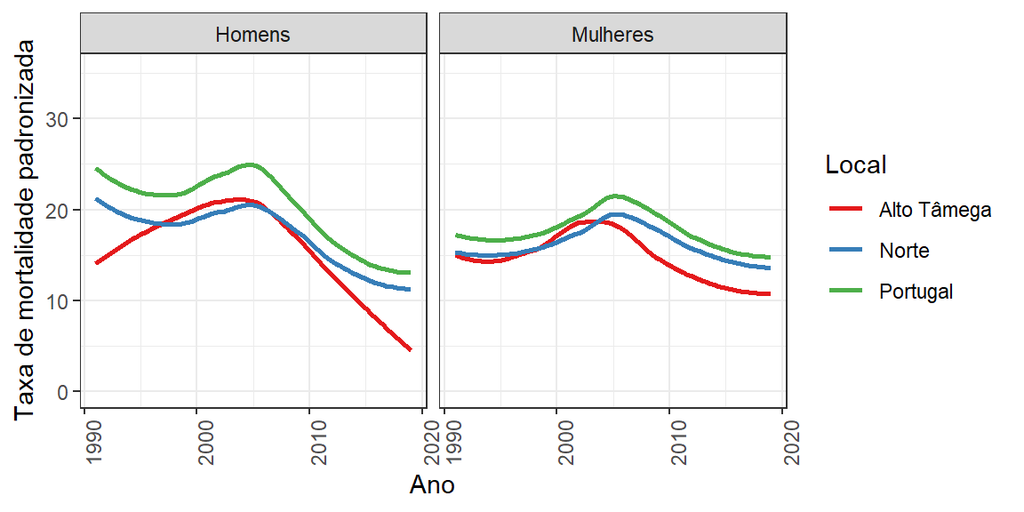

# Complicações da gravidez

## Coluna 1

### Complicações da gravidez, parto e puerpério

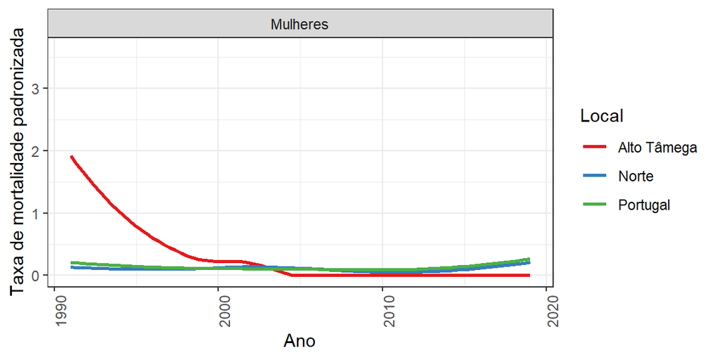

# Doenças perinatais

## Coluna 1

### Algumas afecções originadas no período perinatal

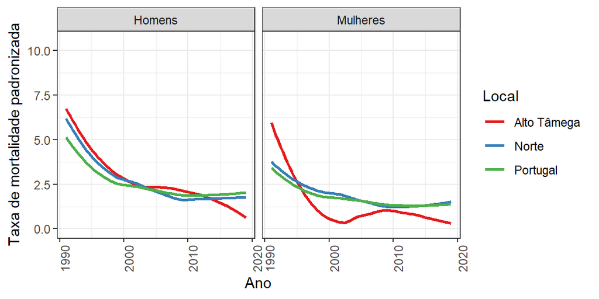

# Malformações congénitas

## Coluna 1

### Malformações congénitas, deformidades e anomalias cromossómicas

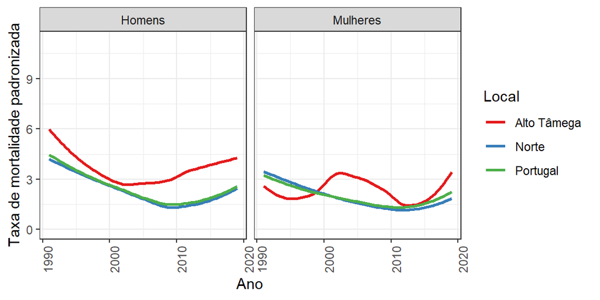

## Coluna 2

### Malformações congénitas do sistema nervoso

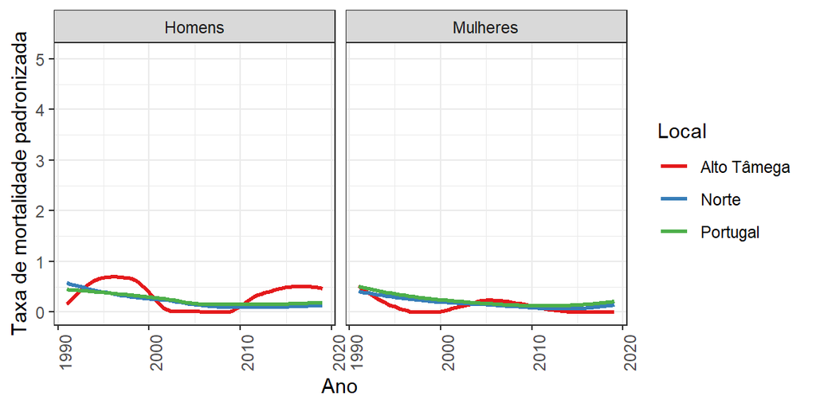

### Malformações congénitas do aparelho circulatório

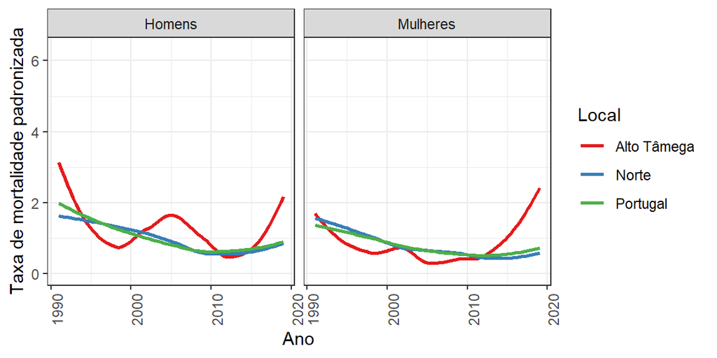

# Sintomas, sinais e exames anormais

## Coluna 1

### Sintomas, sinais e achados anormais de exames clínicos e de laboratório não classificados em outra parte

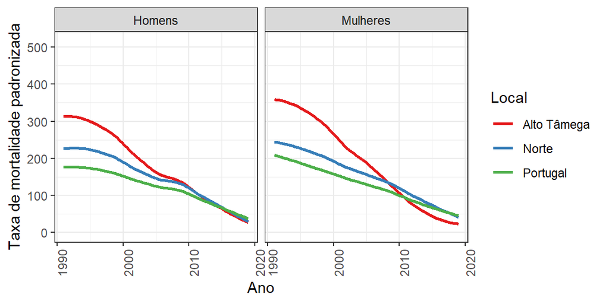

## Coluna 2

### Síndrome de morte súbita do lactente

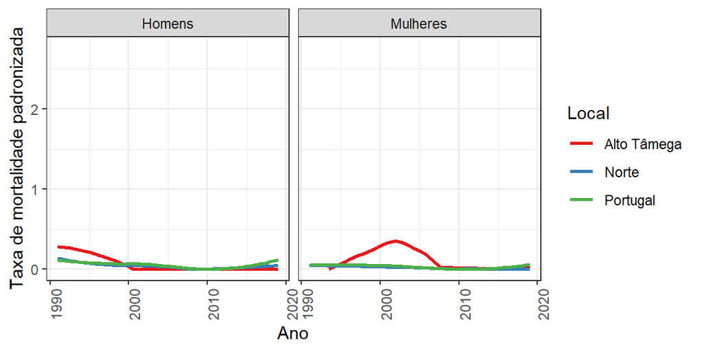

### Outras mortes súbitas de causa desconhecida, mortes sem assistência, outras causas mal definidas e as não especificadas

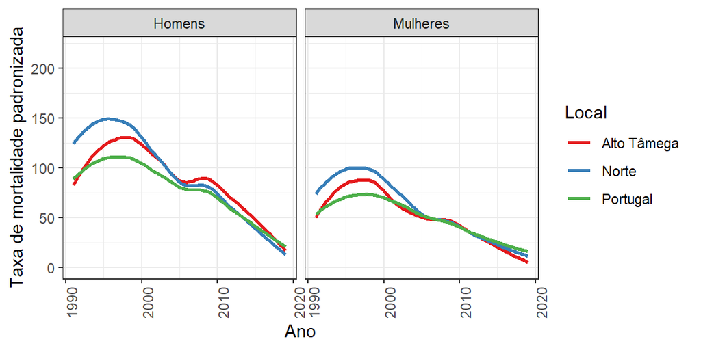

# Causas externas

## Coluna 1

### Causas externas de lesão e envenenamento

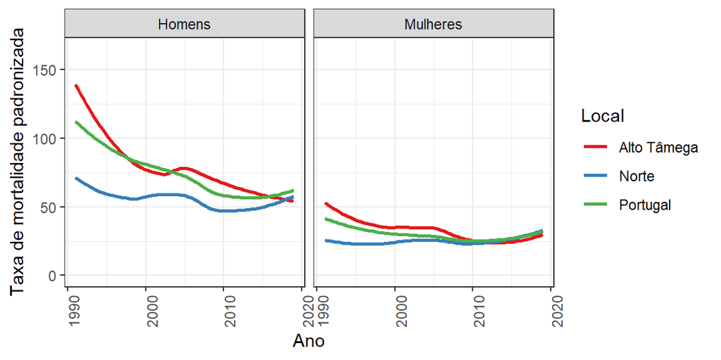

## Coluna 2

### Acidentes

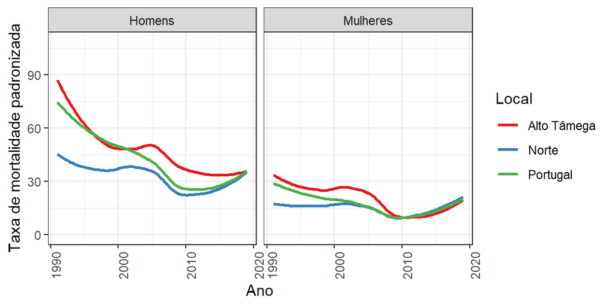

### Acidentes de transporte

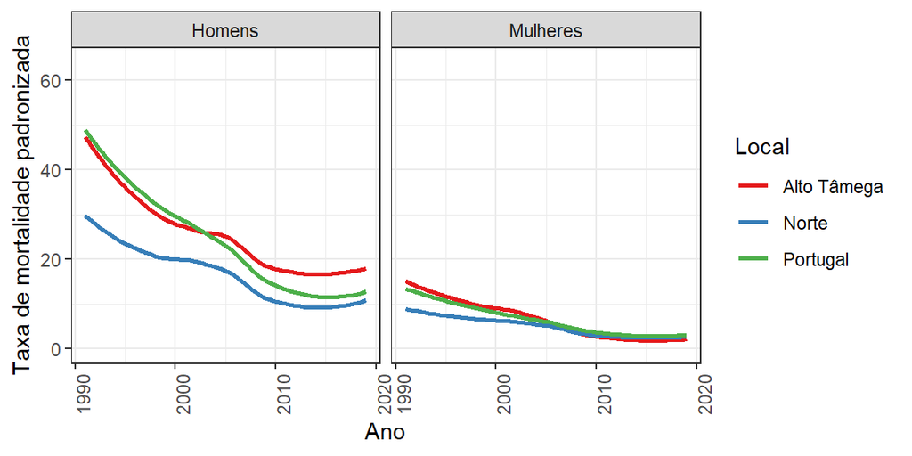

### Quedas acidentais

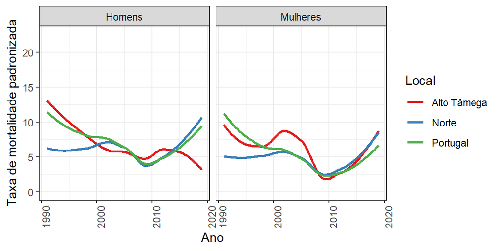

### Envenenamento (intoxicação) acidental por drogas, medicamentos e substâncias biológicas

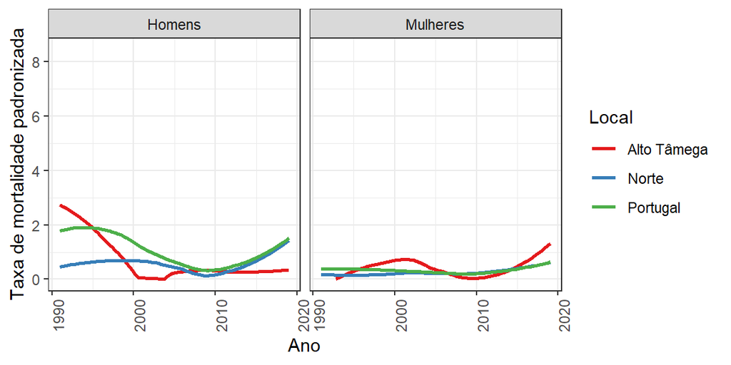

### Suicídios e lesões autoprovocadas voluntariamente

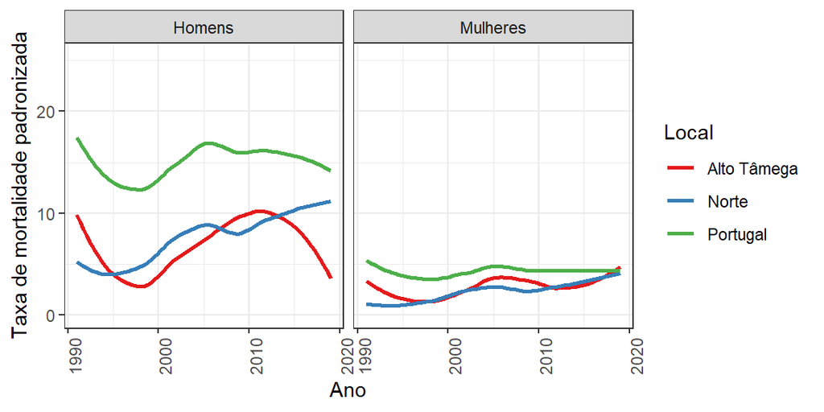

### Homicídios e lesões provocadas intencionalmente por outras pessoas

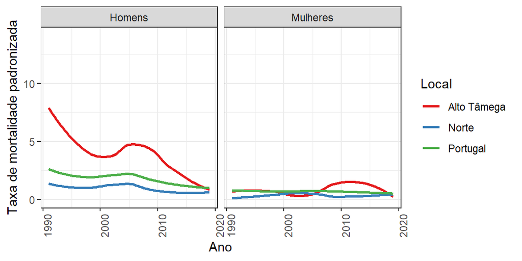

### Lesões em que se ignora se foram acidental ou intencionalmente infligidas

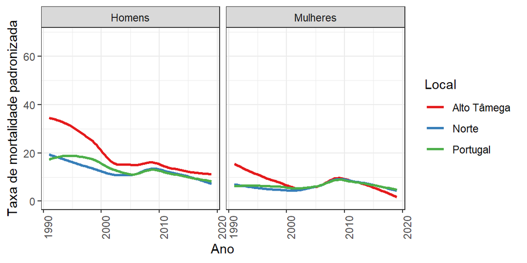

# Covid-19: letalidade

### Letalidade na CIMAT, por mês, desde Março de 2020

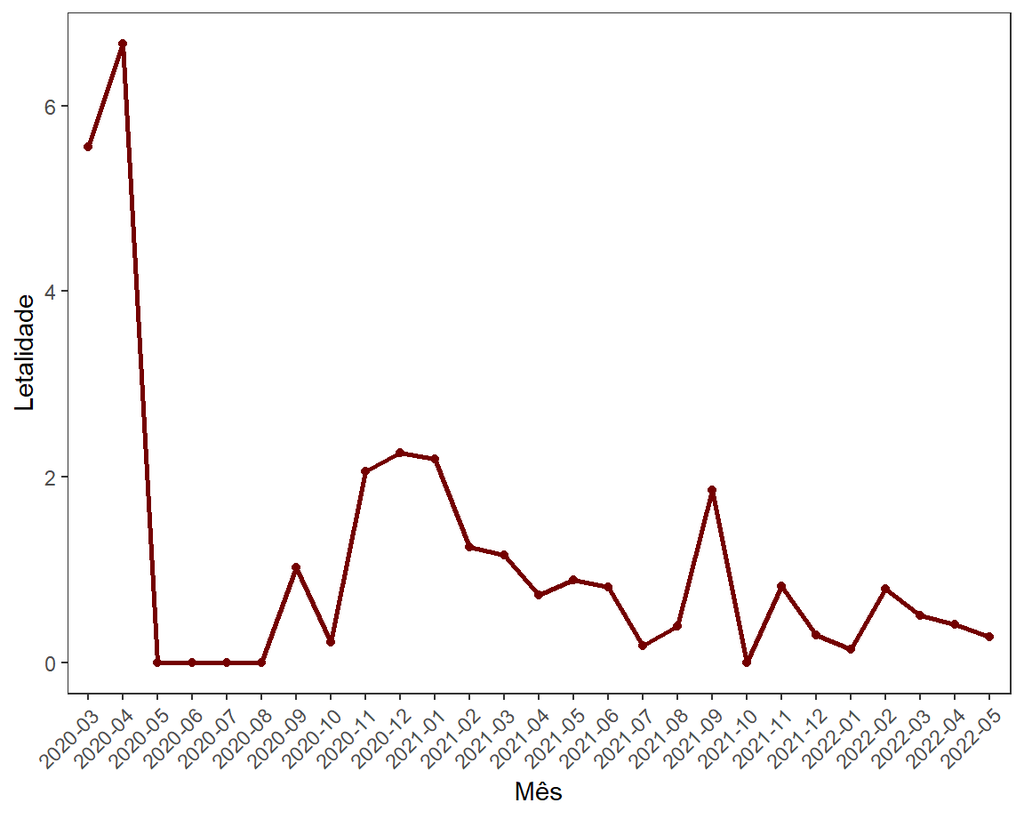

### Explicação e nota metodológica

O gráfico acima apresenta a letalidade da Covid-19, na Comunidade Intermunicipal do Alto Tâmega, por mês, desde Março de 2020.  
A letalidade é a razão entre o número de mortes causadas por uma doença e o número total de indivíduos afectados pela mesma, em determinada área e durante certo período de tempo. Assim, o valor da letalidade representado no gráfico é calculado, dividindo o número de casos de Covid-19 ocorridos em cada mês na Comunidade Intermunicipal do Alto Tâmega que resultaram em óbito, pela totalidade dos casos ocorridos nesse mês.